# Selling SPY Weeklys: 2014 - 2018

A Simple Approach

Pritam Dalal

December 31, 2018

The purpose of this analysis is to backtest a simple strangle selling strategy on SPY weekly options over the last 5 years. This simple trading strategy is a naive version of the one that ODS is analyzing for Parallax.

This report serves as something of a status update for the Parallax backtesting project.

#### Backtesting Parameters

**Dates:** 12/20/2013 - 11/30/2018 (1245 total trading days)

**Underlying:** SPY

**AUM:** $100,000

**Trades:** On each Friday, sell 10-delta strangles that expire the following Friday.

**Hedging Strategies:** Both naked and daily delta-hedged are considered.

#### Premium

Since we are selling options, let’s consider the total the amount of premium sold and total number of options sold. Here is a table of summary statistics:

| tot_prem | avg_prem | tot_opt | avg_opt |
| --- | --- | --- | --- |
| 79408 | 310 | 2465 | 10 |

Notice that we sell just under $80K in premium over the backtest period: $310 per execution, and a total of 256 executions. Each week we sell 10 strangles.

#### Performance

The table below displays performance of the two hedging strategies, as well as the same size investment in the S&P 500.

| strategy | tot_pnl | sharpe_ratio | ret | max_drawdown |
| --- | --- | --- | --- | --- |
| delta_hedge | 22295 | 1.31 | 0.042 | 0.08 |
| naked | 14127 | 0.47 | 0.027 | 0.18 |
| spy | 50474 | 0.80 | 0.086 | 0.14 |

Let’s parse the performance of the delta-hedged strategy in greater detail. Of the $80K of premium sold, $22K is retained, which equates to an annualized return of 4.2%; the Sharpe-Ratio for this strategy was 1.31. Compare this to investing in the S&P 500 which had returns of 8.6% and an SR of 0.80.

Note: this PNL does not account for option commissions.

#### Visualizing Cumulative Performance

The the trade-to-date PNL graphs of these strategies are representative of the nature of naive option selling. Everything is great…until it isn’t.

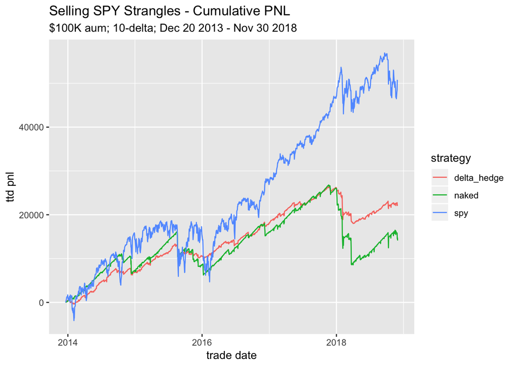

#### PNL by Year

If we examine the PNL by year, we see that the worst year for option selling was 2018. During the backtest period, the SP&500 significantly outperforms option selling in all years except for 2015.

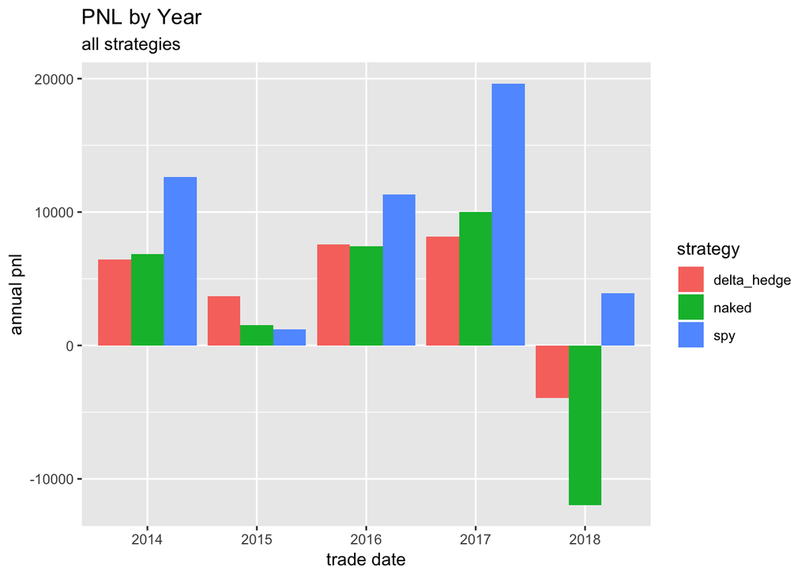

#### Delta-Hedged PNL by Month

Let’s take a closer look at the monthly PNL of the delta-hedged strategy. Notice that significant losses occurred on August 2015, and in the first quarter of 2018. Other than that, things look pretty good.

This suggests an opportunity for performance enhancement via stop-loss mechanisms.

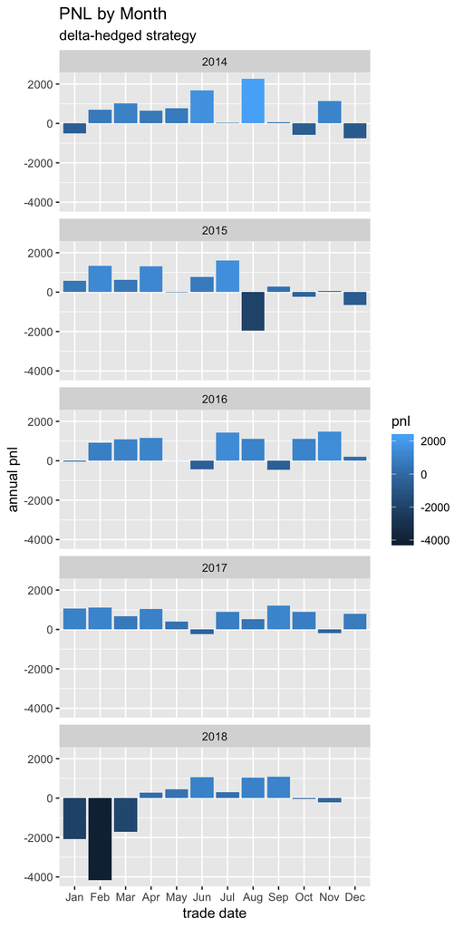

#### Next Steps

My initial delivery date was set for December 31, 2018. Unfortunately, I’m simply not going to be able to hit that deadline. As usual, all data-related projects take so much longer than I anticipate.

I now have five years of historical data in my database, which is what allowed me to produce this report. Additionally, I moved a lot of my backtesting code into a proper R package. This took quite a bit of time, and learning, but was necessary to make sure that my analysis code stays organized and is scalable. In any case, my apologies for the delay.

Here are the next steps for us to work on:

1. I am in the process of using the `rugarch` package to generate GARCH(1,1) estimates for future volatility.
2. You are working the local min/max determination.
3. Based on the two steps above, we will have an execution decision for each expiration date. This execution decision will consist of what to sell (put, strangle, call), and what day to sell it.
4. Once these first three are complete, we can generate the PNLs for the unhedged positions (or daily delta-hedged positions). An immediate sanity check we can do is to make sure that these daily/unhedged pnls perform better than the naive strategy outlined in this current report. If there isn’t an improvement in performance, then our “smarter decision making” isn’t really helping.
5. Next, we will define the risk-management portion of the strategy. This involves some form of delta-hedging, and a stop-loss mechanism for all the trades under extreme circumstances.
6. All of the above can be calculated in absolute dollar terms, and along the way we will be making rough estimates on capital usage. The final stages is to figure out exactly how much capital it will take to fund this strategy, so we can know precise return numbers.

**Revised Delivery Date:** Friday, January 18th.